```python
from IPython.display import HTML

HTML('''<script>
code_show=true;
function code_toggle() {
 if (code_show){
 $('div.input').hide();
 } else {
 $('div.input').show();
 }
 code_show = !code_show
}
$( document ).ready(code_toggle);
</script>
<i>The raw code for this IPython notebook is by default hidden for easier reading.
To toggle on/off the raw code, click <a href="javascript:code_toggle()">here</a>.</i>''')
```

*The raw code for this IPython notebook is by default hidden for easier reading. To toggle on/off the raw code, click here.*

# COVID19 Risk Factors Part 1: Demography, Behavior, Environment, and Personal Health

#### Authors: Gratiana Fu, Greg Maly, and Jamie Parr

*This analysis is Part 1 of a multi-part series on known risk factors associated with COVID-19. We aim to use publicy available datasets to identify national and subnational populations most at risk of hightened mortality rates. This paper will be updated as we identify both new theories and datasets.*

## Introduction

As COVID-19 continues to spread across the world, one of the greatest challenges to response efforts is a lack of data and evidence about infection and mortality rates. We will learn more about the virus and the populations most at risk as more test kits arrive in the hands of physicians. Ideally, this information will be used to help target response efforts, guide policy decisions, inform the donor community, and support decision-making by organizations whose work spans multiple countries, and may need to sustain long-term relief efforts. As a global development company with projects [all over the world](https://www.dai.com/extras/maps/index.html), this kind of information is invaluable as we think about ways to support our staff and prepare for what comes next.

Information from the earliest confirmed cases of COVID-19 indicates that some groups of people are at a higher risk for infection than others. Public health organizations like the WHO and US CDC have [released warnings](https://www.cdc.gov/coronavirus/2019-ncov/specific-groups/high-risk-complications.html) for those at higher risk to take extra precautionary measures. To help DAI and other global development organizations better understand vulnerabilities in the communities in which they work, the DAI Global Health and the Center for Digital Acceleration are tracking these risk factors, in addition to other potential correlates to mortality rates.

In this first of a multi-part series, we will keep an updated record of demographic, socio-economic, personal health, and environmental factors that are perceived to being correlated with heightened risk of mortality, and identify known country and subnational datasets that can help us identify regions at risk. We will supplement this analysis with charts and maps.

# Theories

*NOTE: THIS SECTION WILL BE UPDATED AS WE LEARN MORE ABOUT RISK FACTORS*

Below is a list of factors that have emerged as known drivers of increasing risk of mortality. Some of these theories are based on information released by official public health bodies while others are factors that could be proxies. As we learn more about possible drivers from the medical community, we will update this analysis with new datasets when possible.

1. Factor 1: Age - People over the age of 65+ are at higher risk (CDC)
2. Factor 2: Smoking - People who smoke are at higher risk (CDC)
3. Factor 3: Air Pollution - People living in countries with higher air pollution are at higher risk
4. People who have serious chronic medical conditions are at higher risk (CDC). These conditions include:
   1. Heart disease
   2. Diabetes
   3. Lung disease
   4. People who have hypertension are at higher risk (Bloomberg News)

# Analysis

Our analysis pulls from publicly available datasets from a variety of official and reliable data sources.

| Indicator | Data Source | Year |
| --- | --- | --- |
| Number of confirmed cases of COVID-19 | [JHU](https://github.com/CSSEGISandData/2019-nCoV) | 2020 |
| Number of confirmed deaths due to COVID-19 | [JHU](https://github.com/CSSEGISandData/2019-nCoV) | 2020 |
| Percent of population, age 65+ | [World Bank](https://data.worldbank.org/indicator/SP.POP.65UP.TO.ZS) | 2018 |
| Smoking prevalence, total (ages 15+) | [World Bank](https://data.worldbank.org/indicator/SH.PRV.SMOK) | 2016 |
| PM2.5 air pollution, mean annual exposure (micrograms per cubic meter) | [World Bank](https://data.worldbank.org/indicator/EN.ATM.PM25.MC.M3) | 2017 |
| DALYs due to Cardiovascular Disease | [GBD](http://ghdx.healthdata.org/) | 2017 |
| Percentage of people ages 20-79 who have type 1 or type 2 diabetes | [World Bank](https://data.worldbank.org/indicator/SH.STA.DIAB.ZS) | 2019 |
| DALYs due to Chronic Respiratory Diseases | [GBD](http://ghdx.healthdata.org/) | 2017 |
| Prevalence of raised blood pressure (SBP≥140 OR DBP≥90) | WHO) | 2015 |

## Factor 1: Age

Age has been noted by all official public health organizations as a risk for getting very sick from COVID-19, specifically older adults. Data from the earliest cases in China, Italy, and South Korea have shown that mortality rates are higher among older adults. Using data from the World Bank in 2018, we looked at the percentage of the population aged 65 years old and older in each country. The map below shows the global distribution of these older adults - the darker color indicates a larger percentage of the country population while the lighter indicates a smaller percentage.

```python
from IPython.display import Image, IFrame, display
IFrame(src='images/pop_over_65.html', width=700, height=600)
```

[interactive chart not shown]

```python
from IPython.display import HTML, display
display(HTML("<table><tr><td><img src='images/pop_over_65_hist.png'></td><td><img src='images/pop_over_65_bar.png'></td></tr></table>"))
```

[output not shown]

## Factor 2: Smoking

Research on confirmed cases in China indicates that individuals with cardiovascular and respiratory conditions caused by tobacco use or otherwise are at higher risk of developing severe COVID-19 symptoms and [the crude mortality ratio is significantly higher among those with cardiovascular or chronic respiratory disease than those with no pre-existing medical conditions](http://www.emro.who.int/tfi/know-the-truth/tobacco-and-waterpipe-users-are-at-increased-risk-of-covid-19-infection.html). Consequently, one may expect countries with higher rates of smoking to also be at greater risk in suffering increased pressure on their health systems in responding to COVID-19.

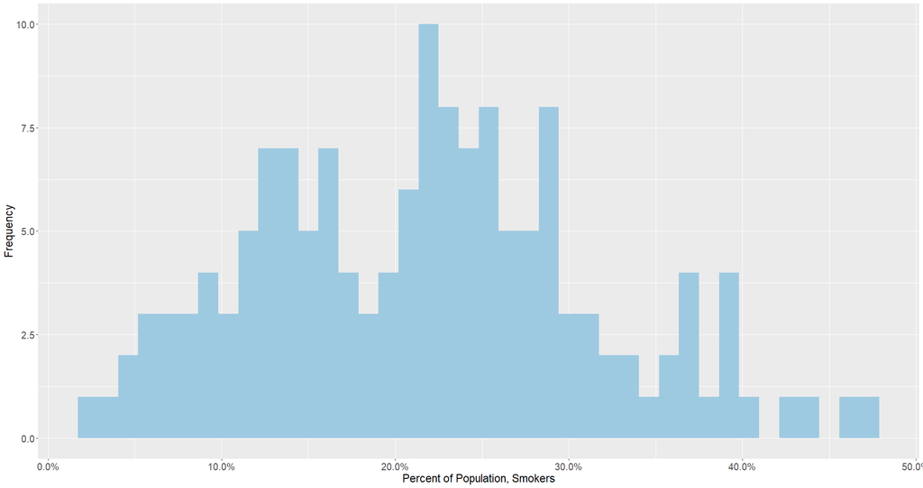

```python
Image('images/Smoking_hist.png')
```

In the graph below, the top twenty-five countries in smoking rates all fall above the 30% line. One aspect of smoking is many countries that share common cultural practices from the same regions appear together: there is significant representation of countries from the Oceania, MENA, and Eastern and Southern Europe regions. While most countries in this graph do not appear in the Age +65 section, there are a few notable exceptions from Southern and Eastern Europe. Among others, Greece, Bulgaria, Estonia, Hungary, and Germany all might face increased stress as the number of cases intensify.

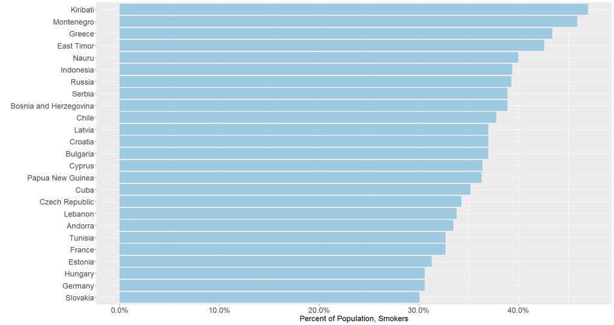

```python
Image('Smoking_bar.png')
```

## Factor 3: Air Pollution

For many of the same reasons mentioned with regards to smoking, exposure to air pollution is a major concern as it relates to coronavirus. The PM2.5 air pollution, mean annual exposure (micrograms per cubic meter) of the Global Burden of Disease Study (2017) provides some indication of which countries are at particular risk.

Exposure to air pollution has a significant amount of variance between countries, as the histogram below displays. While the majority of countries are below 25%, a significant amount of outliers remain.

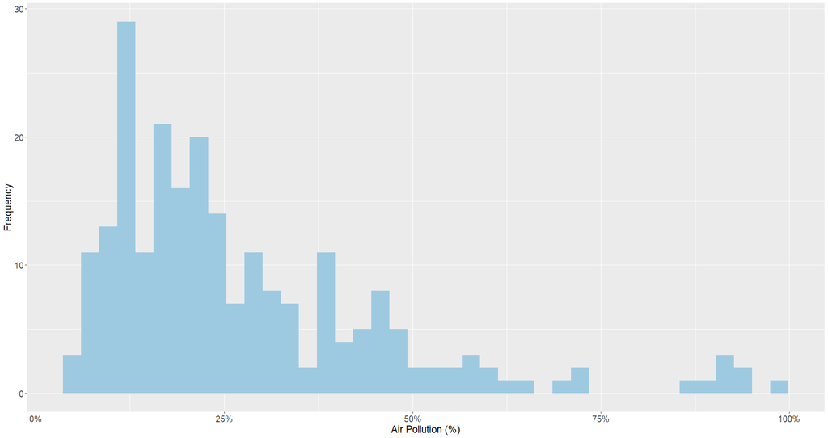

```python
Image('images/Air Pollution_hist.png')
```

The graph below displaying the top countries by exposure to air pollution shows a different set of countries than before. There is greater representation of low and middle-income countries in this graph. In some cases, this can be attributable to the greater economic presence of heavy industry in these countries. Several countries where DAI has a strong presence have particularly high air pollution exposure rates, including Nepal, Uganda, Libya, Iraq, Pakistan, Egypt, Nigeria, and Afghanistan.

[figure not shown]

```python
Image('images/Air Pollution_bar.png')
```

Finally, it is worth noting potential identification issues and the presence of mediating factors in dealing with this variable. Several other variables, most notably the percent of labor force working in industry and population density, are all correlated at the country level. At a more granular level, it remains unclear how these factors will interact and what effect they will have on infection and mortality rates. Will individuals working in industry living in these countries be at greater risk than those who do not? Will countries with greater population density rates suffer higher infection rates, thereby leading to higher mortality rates for countries with worse air quality? Only with more data will we be able to answer this question more precisely.

# Underlying Medical Conditions

In addition to these demographic and external factors, the [WHO released warnings](https://www.who.int/images/default-source/health-topics/coronavirus/social-media-squares/be-safe.jpg) to people with underlying medical conditions to avoid crowded places as these conditions put people at greater risk for infection and death. These conditions specifically noted:

1. Cardiovascular (Heart) disease
2. Respiratory condition
3. Diabetes

We pulled data from the Global Burden of Disease Study 2017 on Disability Adjusted Life Years (DALYs) lost due to cardiovascular disease and chronic respiratory disease and World Bank data from 2019 on country prevalence of type 1 & 2 diabetes. DALYs are a commonly used measure of disease burden expressed as the number of years lost due to illness, disability, or early death.

## Factor 4: Cardiovascular Disease

The global distribution of DALYs due to cardiovascular diseases is shown below. From this, we can see that Eastern Europe is more affected by cardiovascular diseases, indicated by the darker purple color.

```python
IFrame(src='images/DALYs, Cardiovascular Disease (2017).html', width=700, height=600)
```

[interactive chart not shown]

## Factor 5: Respiratory Condition

Respiratory conditions put people at higher risk for COVID-19. [Symptoms of the virus](https://www.sciencedirect.com/science/article/pii/S0896841120300469?via%3Dihub) include pneumonia, sneezing, and sore throat - all conditions that affect the respiratory system. We used data from the Global Burden of Disease Study 2017 to identify disease burden (measured in DALYs) due to all chronic respiratory diseases. This broader category of diseases includes silicosis, asthma, and lung disease.

No major trends appear in the map below. We can see a mild concentration of respiratory conditions in Southeast Asia. North Korea and Papua New Guinea, however, are most affected by these conditions.

```python
IFrame(src='images/DALYs, Chronic Respiratory Disease (2017).html', width=700, height=600)
```

[interactive chart not shown]

```python
display(HTML("<table><tr><td><img src='images/DALYs, Chronic Respiratory Disease (2017)_bar.png'></td><td><img src='images/DALYs, Chronic Respiratory Disease (2017)_hist.png'></td></tr></table>"))
#display(Image('images/DALYs, Chronic Respiratory Disease (2017)_bar.png'), Image('images/DALYs, Chronic Respiratory Disease (2017)_hist.png'))
```

[output not shown]

# Factor 6: Diabetes

```python
IFrame(src='images/Prevalence Diabetes (2019).html', width=700, height=600)
```

[interactive chart not shown]

```python
display(HTML("<table><tr><td><img src='images/Prevalence Diabetes (2019)_hist.png'></td><td><img src='images/Prevalence Diabetes (2019)_bar.png'></td></tr></table>"))

#display(Image('images/Prevalence Diabetes (2019)_bar.png'), Image('images/Prevalence Diabetes (2019)_hist.png'))
```

[output not shown]

# Factor 7: Hypertension

Hypertension, also known as high blood pressure, is the last medical condition that we are looking at.

```python
IFrame(src='images/Percent High Blood Pressure (2015).html', width=700, height=600)
```

[interactive chart not shown]

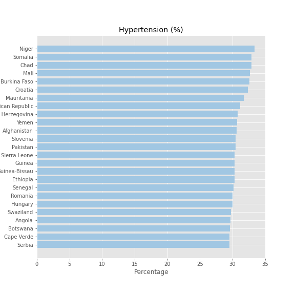

```python
display(Image('images/Percent High Blood Pressure (2015)_bar.png'))
```